# 市场观察

2017/05/09

## A、指数估值

### (a1)动态市盈率、市净率

核心指数成分股近18个月的动态市盈率及动态市净率中位数走势如下图所示：

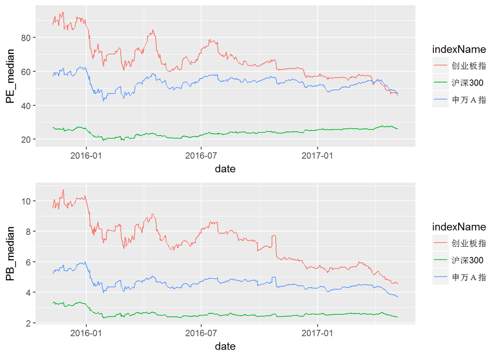

### (a2)动态市盈率、市净率百分位

核心指数近18个月的动态市盈率百分位及动态市净率百分位走势如下图所示：

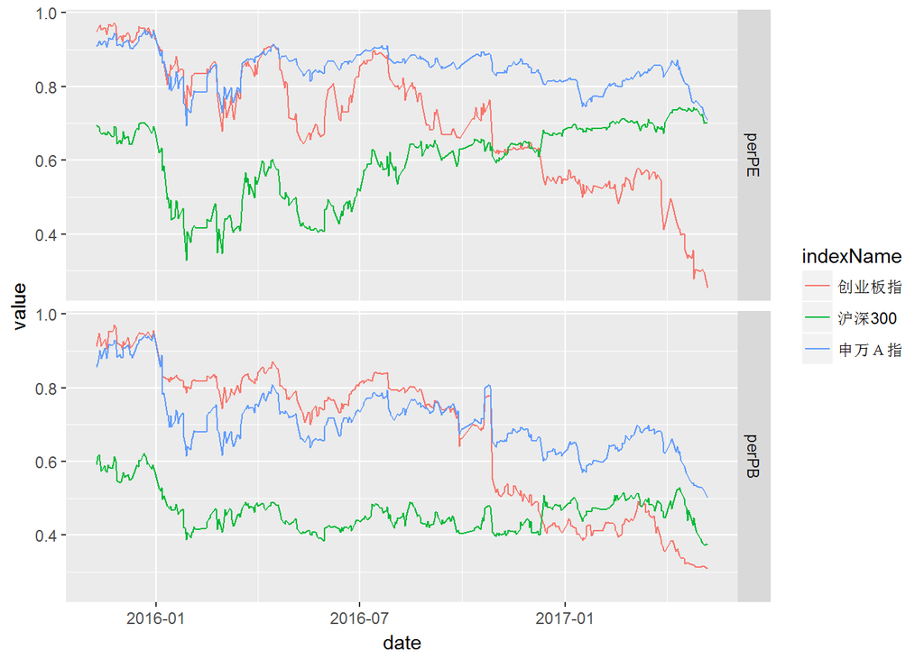

### (a3)指数估值概览

| 指数代码 | 指数简称 | 日期 | 动态市盈率 | 市盈率百分位 | 动态市净率 | 市净率百分位 |
| --- | --- | --- | --- | --- | --- | --- |
| EI801003 | 申万Ａ指 | 2017-05-08 | 46.9 | 71% | 3.7 | 50% |
| EI399330 | 深证100 | 2017-05-08 | 31.1 | 63% | 3.5 | 45% |
| EI000300 | 沪深300 | 2017-05-08 | 26.2 | 70% | 2.4 | 38% |
| EI399959 | 军工指数 | 2017-05-08 | 83.7 | 58% | 3.9 | 48% |
| EI000979 | 大宗商品 | 2017-05-08 | 31.9 | 59% | 2.5 | 41% |
| EI000819 | 有色金属 | 2017-05-08 | 51.5 | 68% | 2.9 | 22% |
| EI399005 | 中小板指P | 2017-05-08 | 38.6 | 55% | 4.2 | 33% |
| EI000016 | 上证50 | 2017-05-08 | 18.5 | 66% | 1.5 | 8% |
| EI000905 | 中证500 | 2017-05-08 | 35.0 | 44% | 2.8 | 29% |
| EI000934 | 中证金融 | 2017-05-08 | 18.6 | 58% | 1.7 | 7% |
| EI000998 | 中证TMT | 2017-05-08 | 40.4 | 34% | 3.7 | 30% |
| EI399006 | 创业板指 | 2017-05-08 | 45.6 | 25% | 4.5 | 31% |
| EI000827 | 中证环保 | 2017-05-08 | 35.5 | 28% | 2.7 | 14% |
| EI000922 | 中证红利 | 2017-05-08 | 15.2 | 20% | 1.6 | 11% |
| EI000932 | 中证消费 | 2017-05-08 | 28.4 | 18% | 3.4 | 4% |
| EI000933 | 中证医药 | 2017-05-08 | 31.8 | 15% | 3.5 | 1% |

### (a4)另类估值

我国10年期国债收益率、金银比价、金油比价，2000年以来的历史百分位如下图所示：

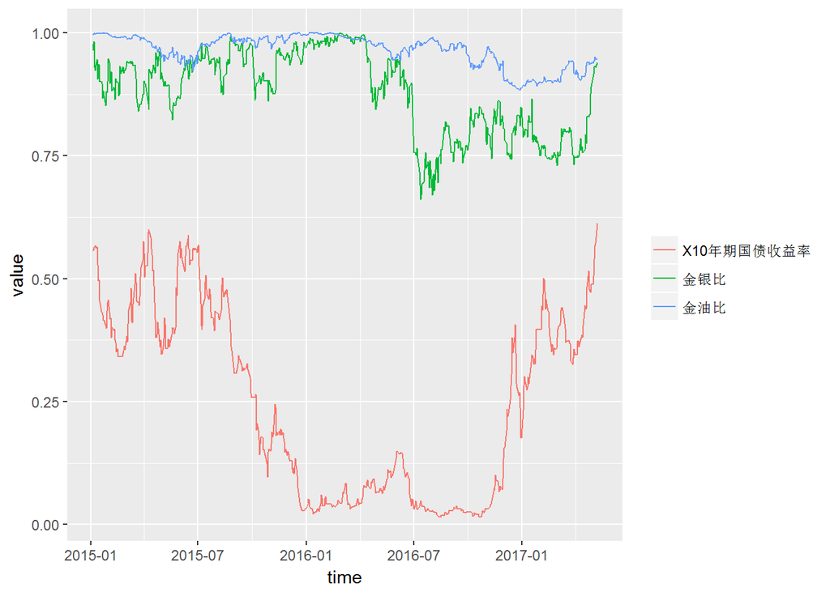

## B、基差及市场情绪

### (b1)基差走势

三大股指期货合约基差走势如下图，其中当月合约和次月合约年化基差百分比波动较大，仅展示合约基差百分比，当季合约和次季合约展示基差年化百分比：

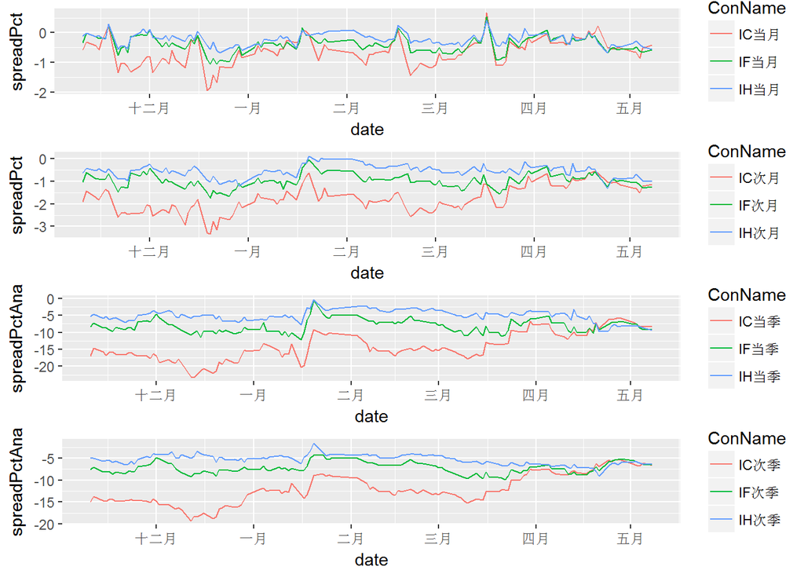

### (b2)基差概况

三大股指期货连续合约基差概况如下表，近月合约临近到期日，年化基差百分比数据波动较大：

| 日期 | 合约代码 | 合约收盘价 | 指数收盘价 | 基差 | 基差百分比 | 年化基差百分比 |
| --- | --- | --- | --- | --- | --- | --- |
| 2017-05-08 | IC1705 | 5951.2 | 5975.5 | -24.3 | -0.4% | -14.4% |
| 2017-05-08 | IC1706 | 5908.0 | 5975.5 | -67.5 | -1.1% | -11.1% |
| 2017-05-08 | IC1709 | 5805.0 | 5975.5 | -170.5 | -2.9% | -8.2% |
| 2017-05-08 | IC1712 | 5737.8 | 5975.5 | -237.7 | -4.0% | -6.7% |
| 2017-05-08 | IF1705 | 3339.4 | 3358.8 | -19.4 | -0.6% | -21.1% |
| 2017-05-08 | IF1706 | 3317.4 | 3358.8 | -41.4 | -1.2% | -12.2% |
| 2017-05-08 | IF1709 | 3251.2 | 3358.8 | -107.6 | -3.2% | -9.3% |
| 2017-05-08 | IF1712 | 3227.4 | 3358.8 | -131.4 | -3.9% | -6.5% |
| 2017-05-08 | IH1705 | 2313.2 | 2326.1 | -12.9 | -0.6% | -20.1% |
| 2017-05-08 | IH1706 | 2302.4 | 2326.1 | -23.7 | -1.0% | -10.0% |
| 2017-05-08 | IH1709 | 2250.4 | 2326.1 | -75.7 | -3.3% | -9.4% |
| 2017-05-08 | IH1712 | 2239.0 | 2326.1 | -87.1 | -3.7% | -6.3% |

### (b3)市场情绪(provided by han.qian)

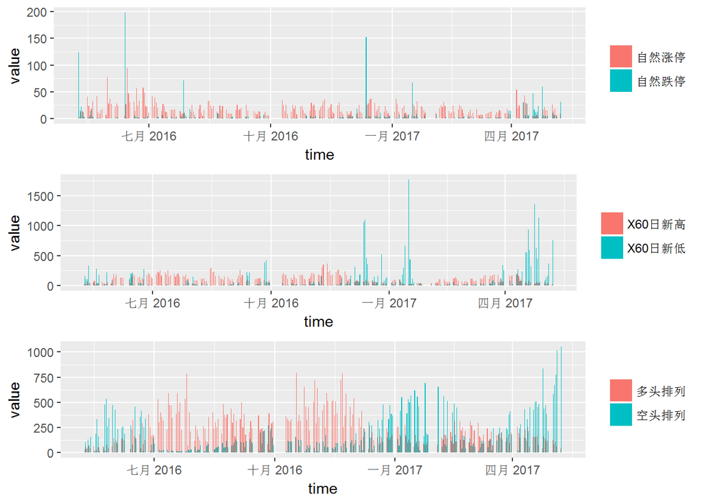

## C、套利和事件

### (c1)复牌股票套利

近两天复牌股票套利情况如下表：

[1] “No qualified index!”

[1] “No Arbitrage!”

### (c2)定增基金(provided by han.qian)

定增基金数据如下表，明细数据参见钱瀚的模板。

| 代码 | 名称 | 到期日期 | 最新净值 | 昨日收盘价 | 折溢价率 | 整体隐含折价率 | 大盘下跌0.1净值变化 |
| --- | --- | --- | --- | --- | --- | --- | --- |
| 168101.OF | 九泰锐智 | 20200814 | 1.15 | 1.00 | -12.6% | 3.0% | -10.0% |
| 168102.OF | 九泰锐富 | 20210204 | 1.00 | 0.83 | -16.5% | 2.3% | -5.6% |
| 501015.OF | 财通升级 | 20170908 | 0.98 | 0.95 | -3.2% | 1.3% | -9.0% |
| 160518.OF | 博时睿远 | 20171016 | 0.95 | 0.90 | -5.1% | 0.8% | -6.6% |

定增基金近期的净值走势如下图：

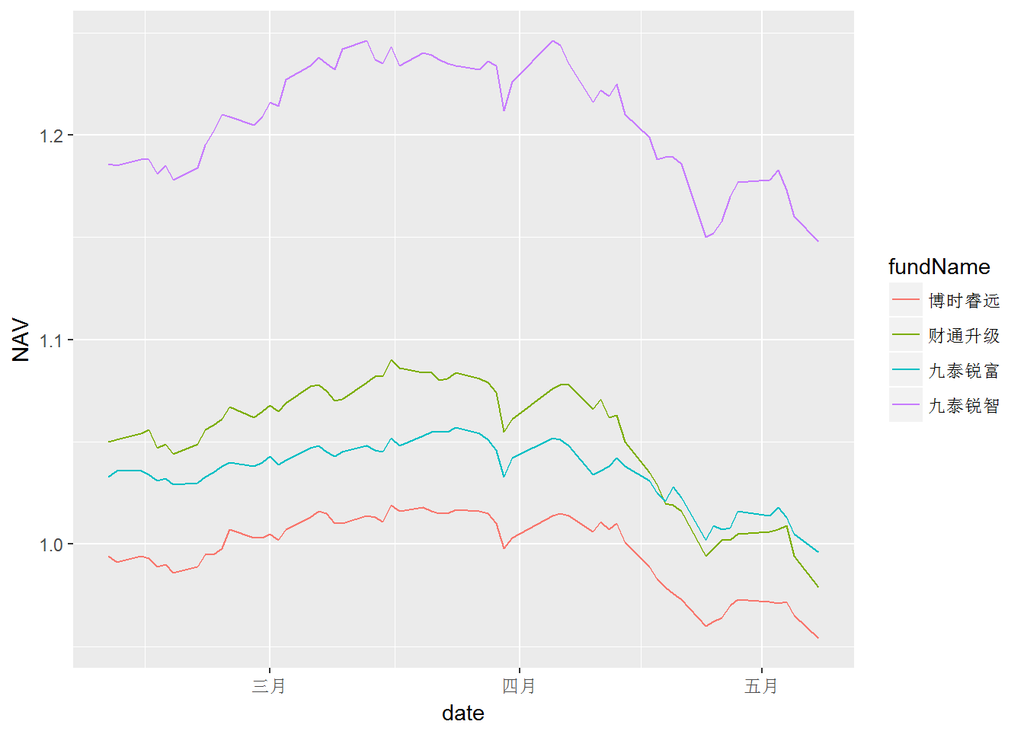

定增基金近期的折溢价率百分比走势如下图：

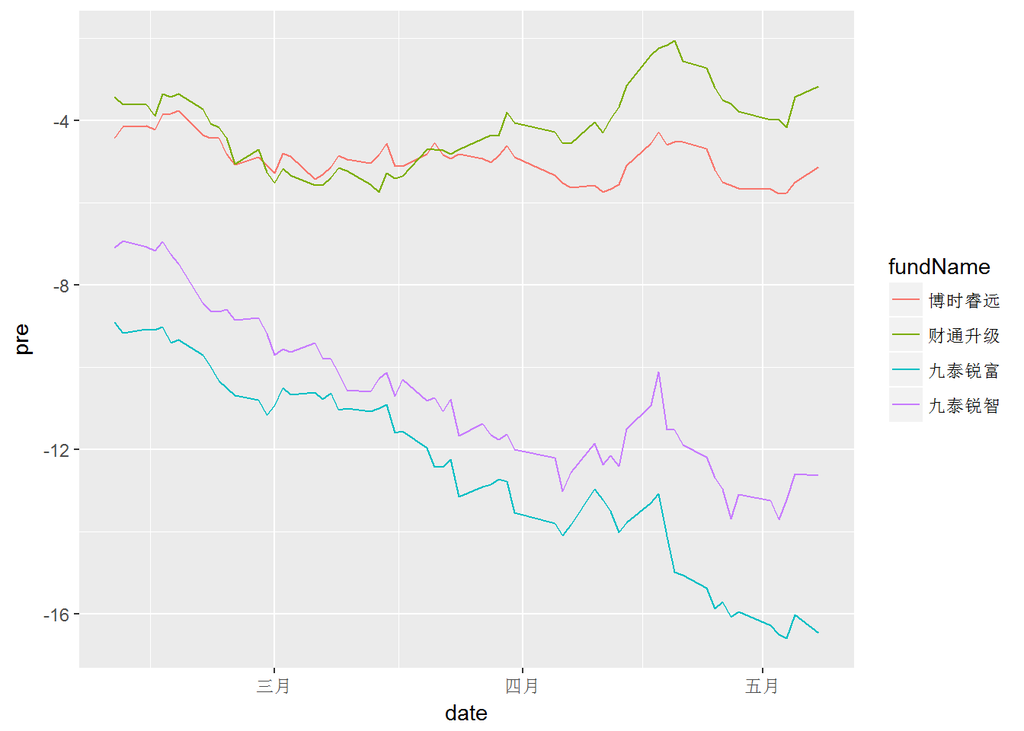

### (c3)定增解禁(provided by han.qian)

近十天定增解禁的股票情况如下表。

| 股票代码 | 股票简称 | 起始跟踪日 | 解禁日 | 解禁百分比 | 区间涨跌幅 | 所属行业指数 | 行业指数涨跌幅 |
| --- | --- | --- | --- | --- | --- | --- | --- |
| EQ000887 | 中鼎股份 | 2017-04-21 | 2017-05-08 | 8% | -2.7% | 申万汽车 | -5.0% |
| EQ002335 | 科华恒盛 | 2017-04-21 | 2017-05-08 | 19% | -15.1% | 申万电气设备 | -6.4% |
| EQ002654 | 万润科技 | 2017-04-21 | 2017-05-08 | 7% | -11.2% | 申万电子 | -2.6% |
| EQ300343 | 联创互联 | 2017-04-24 | 2017-05-09 | 20% | -2.1% | 申万传媒 | -1.4% |
| EQ300353 | 东土科技 | 2017-04-24 | 2017-05-09 | 8% | -16.5% | 申万通信 | -3.8% |
| EQ600565 | 迪马股份 | 2017-04-24 | 2017-05-09 | 59% | -13.8% | 申万房地产 | -6.3% |
| EQ002642 | 荣 之 联 | 2017-04-25 | 2017-05-10 | 19% | 0.0% | 申万计算机 | -1.1% |
| EQ300043 | 星辉娱乐 | 2017-04-25 | 2017-05-10 | 9% | -1.8% | 申万传媒 | 0.2% |
| EQ300287 | 飞 利 信 | 2017-04-25 | 2017-05-10 | 18% | 0.1% | 申万计算机 | -1.1% |
| EQ601222 | 林洋能源 | 2017-04-25 | 2017-05-10 | 22% | 1.6% | 申万电气设备 | -2.8% |
| EQ300433 | 蓝思科技 | 2017-04-26 | 2017-05-11 | 75% | -0.4% | 申万电子 | -1.0% |
| EQ603885 | 吉祥航空 | 2017-04-26 | 2017-05-11 | 69% | -1.8% | 申万交通运输 | -1.7% |
| EQ002092 | 中泰化学 | 2017-04-27 | 2017-05-12 | 22% | -4.7% | 申万化工 | -2.2% |
| EQ002004 | 华邦健康 | 2017-04-28 | 2017-05-15 | 8% | -0.1% | 申万化工 | -2.8% |
| EQ600770 | 综艺股份 | 2017-04-28 | 2017-05-15 | 18% | -3.2% | 申万综合 | -5.0% |
| EQ603601 | 再升科技 | 2017-04-28 | 2017-05-15 | 36% | 0.0% | 申万化工 | -2.8% |
| EQ002174 | 游族网络 | 2017-05-02 | 2017-05-16 | 173% | -9.1% | 申万传媒 | -1.5% |
| EQ002390 | 信邦制药 | 2017-05-02 | 2017-05-16 | 8% | 0.0% | 申万医药生物 | -2.6% |
| EQ000420 | 吉林化纤 | 2017-05-03 | 2017-05-17 | 70% | -11.7% | 申万化工 | -3.6% |
| EQ300059 | 东方财富 | 2017-05-03 | 2017-05-17 | 6% | -0.8% | 申万传媒 | -1.2% |
| EQ300166 | 东方国信 | 2017-05-03 | 2017-05-17 | 14% | 5.0% | 申万计算机 | -1.8% |
| EQ002239 | 奥 特 佳 | 2017-05-05 | 2017-05-19 | 11% | -0.8% | 申万汽车 | -2.7% |
| EQ002670 | 国盛金控 | 2017-05-05 | 2017-05-19 | 109% | -7.3% | 申万家用电器 | -1.8% |
| EQ300301 | 长方集团 | 2017-05-05 | 2017-05-20 | 17% | -1.6% | 申万电子 | -3.2% |
| EQ300410 | 正业科技 | 2017-05-05 | 2017-05-19 | 34% | -2.5% | 申万电子 | -3.2% |
| EQ300195 | 长荣股份 | 2017-05-08 | 2017-05-22 | 14% | -0.8% | 申万机械设备 | -2.0% |
| EQ600090 | 同 济 堂 | 2017-05-08 | 2017-05-22 | 91% | -3.4% | 申万食品饮料 | -1.7% |
| EQ002708 | 光洋股份 | 2017-05-09 | 2017-05-23 | 7% | 0.0% | 申万汽车 | 0.0% |

### (c4)中小板业绩预增预测(provided by han.qian)

中小板规定正式财务报告发布的同时需要发布新一期的业绩预报，比如年报中会包含一季报预告的情况。我们假设公司的盈利状况有动量效应，年报预增的公司一季度也会预增，在正式财务报告发布前20个交易日开始埋伏，然后等正式报告发布日卖出。具体研究参见钱瀚前期的研究。需要注意的是这里的收益率仅做展示，仅仅是每日全部入选股票的平均收益率，并没有做成一个事件组合。

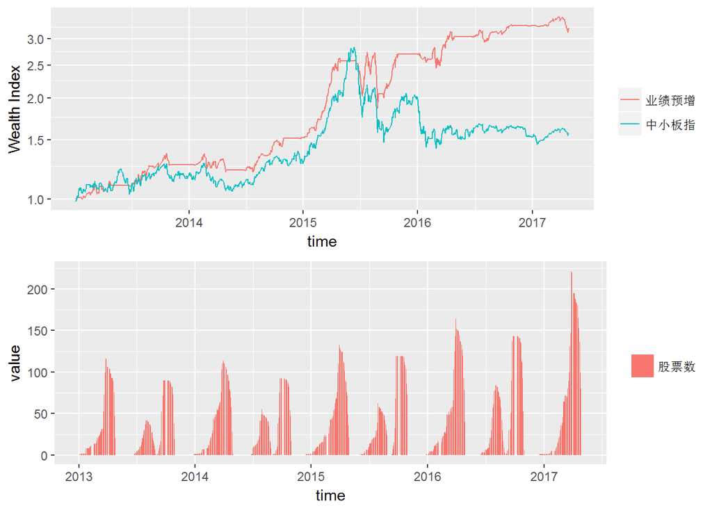

历年收益统计如下表所示。

|  | 业绩预增 | 中小板指 |
| --- | --- | --- |
| 2013-01-04 ~ 2013-12-31 | 26.4% | 17.5% |
| 2014-01-02 ~ 2014-12-31 | 20.4% | 9.7% |
| 2015-01-05 ~ 2015-12-31 | 77.3% | 53.7% |
| 2016-01-04 ~ 2016-12-30 | 21.9% | -22.9% |
| 2017-01-03 ~ 2017-04-28 | -1.5% | 2.6% |
| Cumulative Return | 223.8% | 56.7% |
| Annualized Return | 31.3% | 11.0% |

### (c5)ST摘帽(provided by han.qian)

具体策略可以参见吴先兴的潜伏ST摘帽报告。

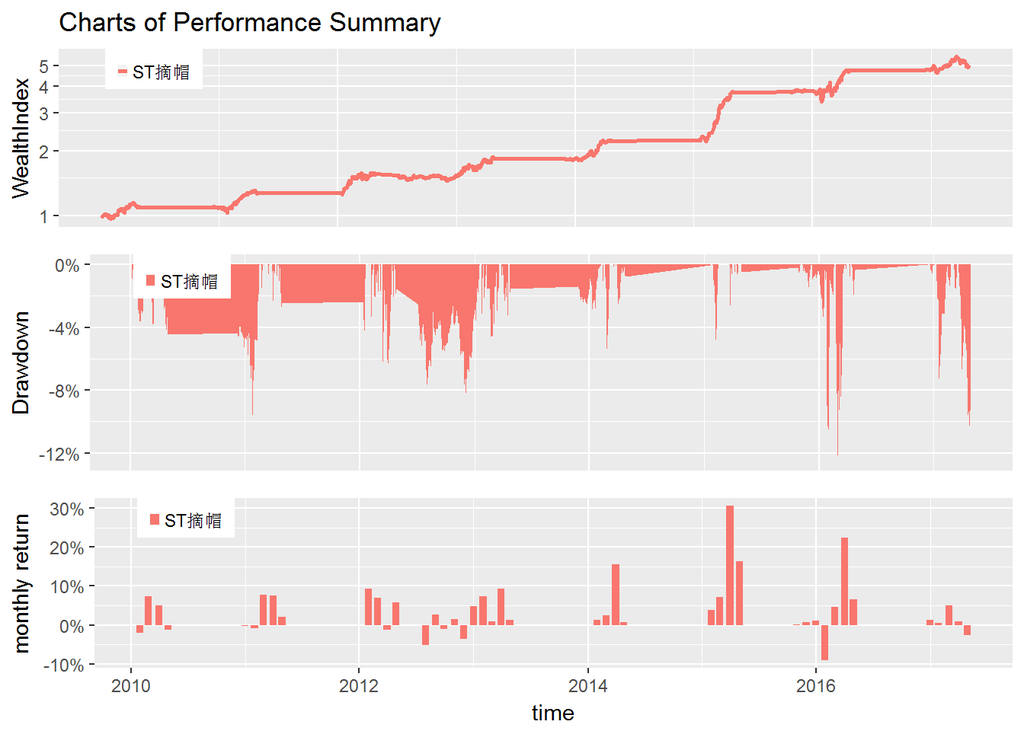

最新持仓如下表所示。

| date | stockID | stockName | wgt |
| --- | --- | --- | --- |
| 2017-04-28 | EQ000505 | *ST 珠江 | 0.1 |
| 2017-04-28 | EQ000511 | *ST 烯碳 | 0.1 |
| 2017-04-28 | EQ600339 | 中油工程 | 0.1 |

### (c6)主动量化基金

主动量化基金最近一年和最近一个季度的收益率密度图如下所示。

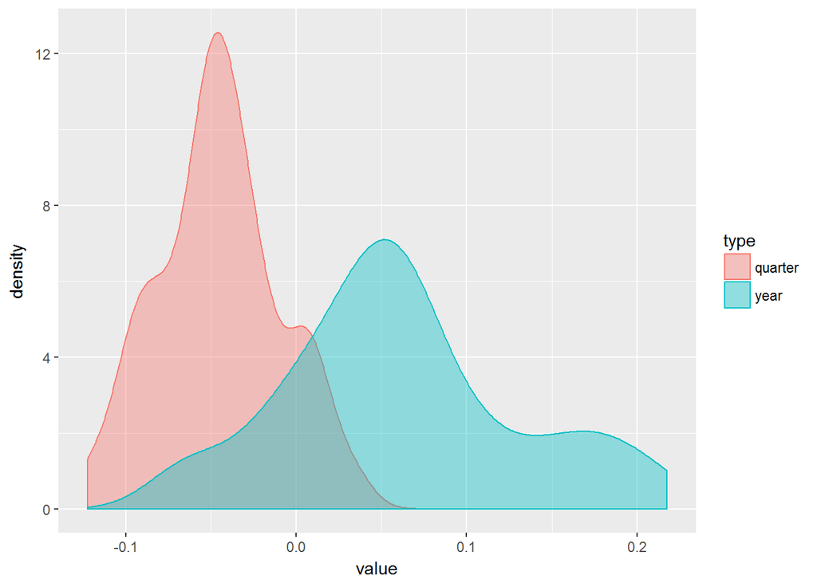

主动量化基金近一年和近一个季度表现最好的20只基金如下表所示。

| 季度排名 | 基金简称 | 成立日 | 总规模 | 季度收益 | 年度排名 | 基金简称 | 成立日 | 总规模 | 年度收益 |
| --- | --- | --- | --- | --- | --- | --- | --- | --- | --- |
| 1 | 金信量化精选 | 2016-07-01 | 2.1 | 3.5% | 1 | 华泰柏瑞量化优选 | 2014-12-17 | 7.2 | 21.8% |
| 2 | 景顺长城量化新动力 | 2016-07-13 | 1.2 | 2.9% | 2 | 华泰柏瑞量化智慧 | 2015-06-03 | 5.3 | 19.5% |
| 3 | 华泰柏瑞量化优选 | 2014-12-17 | 7.2 | 1.3% | 3 | 华泰柏瑞量化先行 | 2010-06-22 | 5.6 | 19.1% |
| 4 | 华泰柏瑞量化先行 | 2010-06-22 | 5.6 | 1.2% | 4 | 华泰柏瑞量化驱动 | 2015-03-24 | 19.5 | 17.4% |
| 5 | 华泰柏瑞量化智慧 | 2015-06-03 | 5.3 | 1.2% | 5 | 华泰柏瑞量化A | 2013-08-02 | 46.7 | 16.6% |
| 6 | 长盛量化红利策略 | 2009-11-25 | 2.5 | 1.0% | 6 | 泰达宏利同顺大数据A | 2016-02-23 | 2.1 | 15.5% |
| 7 | 泰达宏利量化 | 2016-08-30 | 1.9 | 0.6% | 7 | 九泰久盛量化先锋 | 2015-11-10 | 4.5 | 14.2% |
| 8 | 华泰柏瑞量化驱动 | 2015-03-24 | 19.5 | 0.4% | 8 | 泰达宏利逆向策略 | 2012-05-23 | 16.2 | 12.4% |
| 9 | 东吴安鑫量化 | 2016-06-03 | 2.4 | 0.3% | 9 | 景顺长城量化精选 | 2015-02-04 | 13.4 | 11.4% |
| 10 | 华泰柏瑞量化A | 2013-08-02 | 46.7 | 0.1% | 10 | 泰达宏利改革动力A | 2015-02-13 | 18.4 | 10.1% |
| 11 | 华润元大医疗保健量化 | 2014-08-18 | 0.5 | 0.1% | 11 | 申万菱信量化小盘 | 2011-06-16 | 30.9 | 8.8% |
| 12 | 华商量化进取 | 2015-04-09 | 26.7 | -1.3% | 12 | 大成核心双动力 | 2010-06-22 | 1.3 | 8.8% |
| 13 | 长盛医疗行业 | 2016-02-03 | 0.6 | -1.4% | 13 | 华商大盘量化精选 | 2013-04-09 | 12.3 | 8.0% |
| 14 | 民生加银量化中国 | 2016-05-19 | 1.4 | -1.7% | 14 | 长信量化多策略 | 2015-07-14 | 3.3 | 7.7% |
| 15 | 景顺长城量化精选 | 2015-02-04 | 13.4 | -1.8% | 15 | 华富量子生命力 | 2011-04-01 | 0.8 | 7.0% |
| 16 | 建信多因子量化 | 2016-08-09 | 1.9 | -2.0% | 16 | 长盛量化红利策略 | 2009-11-25 | 2.5 | 6.4% |
| 17 | 平安大华量化成长A | 2016-11-02 | 2.0 | -2.7% | 17 | 汇添富成长多因子量化策略 | 2015-02-16 | 17.4 | 6.1% |
| 18 | 泰达宏利同顺大数据A | 2016-02-23 | 2.1 | -2.8% | 18 | 长信量化先锋A | 2010-11-18 | 85.9 | 6.1% |
| 19 | 大成动态量化 | 2016-09-20 | 3.1 | -2.9% | 19 | 南方量化成长 | 2015-06-29 | 14.2 | 6.0% |
| 20 | 平安大华量化成长C | 2016-11-02 | 0.0 | -2.9% | 20 | 南方策略优化 | 2010-03-30 | 13.8 | 5.9% |

## D、择时

### (d1)等权指数

从历史来看，A股市场存在小盘股效应，市值小的股票长期整体跑赢大市值的股票，美股市场同样存在类似的现象。而目前大部分指数的编制方案都是类似市值加权，为了抛去市值的影响，下面展示几个等权指数，其中中证500等权和沪深300等权是现有的指数，中证全指等权是自己编制的指数。等权指数可以视为一个更好地业绩比较基准。等权指数走势如下图：

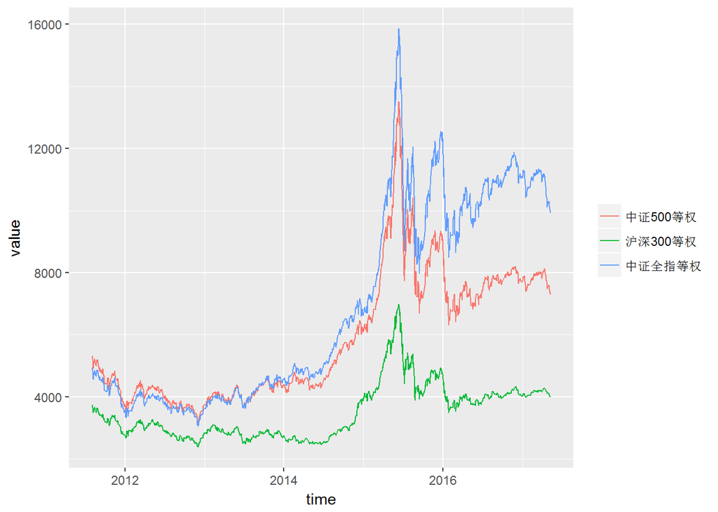

等权指数收益率统计见下表：

|  | 中证500等权 | 沪深300等权 | 中证全指等权 |
| --- | --- | --- | --- |
| 2011-08-02 ~ 2011-12-30 | -29.2% | -25.5% | -27.8% |
| 2012-01-04 ~ 2012-12-31 | -0.0% | 1.5% | 2.2% |
| 2013-01-04 ~ 2013-12-31 | 16.7% | -3.2% | 25.8% |
| 2014-01-02 ~ 2014-12-31 | 40.2% | 43.7% | 46.0% |
| 2015-01-05 ~ 2015-12-31 | 47.6% | 20.1% | 84.4% |
| 2016-01-04 ~ 2016-12-30 | -15.1% | -15.1% | -10.3% |
| 2017-01-03 ~ 2017-05-08 | -5.3% | -0.9% | -10.2% |
| 累计收益率 | 37.5% | 6.4% | 101.5% |
| 年化收益率 | 5.7% | 1.1% | 12.9% |
| 年化波动率 | 28.6% | 25.9% | 28.9% |
| 年化Sharpe值 | 19.9% | 4.2% | 44.6% |
| 最大回撤 | 53.3% | 50.0% | 49.7% |

### (d2)大盘均线强弱指数

大盘均线强弱指数在一定程度上可以视为一个反转指标，当大盘均线得分接近8分时，预示市场接近顶部，当大盘均线得分接近0分时，预示市场接近底部。  
大盘均线强弱指数近一年来走势如下图：

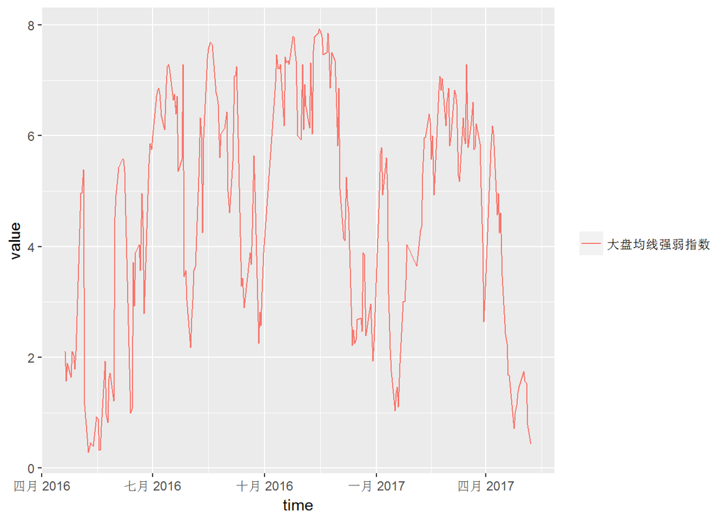

申万一级行业的最新得分见下表：

| 日期 | 指数代码 | 行业 | 最新得分 | 上周得分 |
| --- | --- | --- | --- | --- |
| 2017-05-08 | EI801110 | 家用电器 | 4 | 8 |
| 2017-05-08 | EI801120 | 食品饮料 | 3 | 4 |
| 2017-05-08 | EI801720 | 建筑装饰 | 2 | 3 |
| 2017-05-08 | EI801040 | 钢铁 | 1 | 3 |
| 2017-05-08 | EI801160 | 公用事业 | 1 | 6 |
| 2017-05-08 | EI801710 | 建筑材料 | 1 | 5 |
| 2017-05-08 | EI801010 | 农林牧渔 | 0 | 1 |
| 2017-05-08 | EI801020 | 采掘 | 0 | 1 |
| 2017-05-08 | EI801030 | 化工 | 0 | 1 |
| 2017-05-08 | EI801050 | 有色金属 | 0 | 1 |
| 2017-05-08 | EI801080 | 电子 | 0 | 4 |
| 2017-05-08 | EI801130 | 纺织服装 | 0 | 1 |
| 2017-05-08 | EI801140 | 轻工制造 | 0 | 1 |
| 2017-05-08 | EI801150 | 医药生物 | 0 | 0 |
| 2017-05-08 | EI801170 | 交通运输 | 0 | 4 |
| 2017-05-08 | EI801180 | 房地产 | 0 | 0 |
| 2017-05-08 | EI801200 | 商业贸易 | 0 | 1 |
| 2017-05-08 | EI801210 | 休闲服务 | 0 | 0 |
| 2017-05-08 | EI801230 | 综合 | 0 | 0 |
| 2017-05-08 | EI801730 | 电气设备 | 0 | 0 |
| 2017-05-08 | EI801740 | 国防军工 | 0 | 0 |
| 2017-05-08 | EI801750 | 计算机 | 0 | 0 |
| 2017-05-08 | EI801760 | 传媒 | 0 | 1 |
| 2017-05-08 | EI801770 | 通信 | 0 | 1 |
| 2017-05-08 | EI801780 | 银行 | 0 | 0 |
| 2017-05-08 | EI801790 | 非银金融 | 0 | 2 |
| 2017-05-08 | EI801880 | 汽车 | 0 | 0 |
| 2017-05-08 | EI801890 | 机械设备 | 0 | 1 |

### (d3)LLT及均线择时

LLT本质上是一个改进的单均线择时指标，较原始的均线择时延迟更低。  
择时模型和指数本身的净值走势如下图：

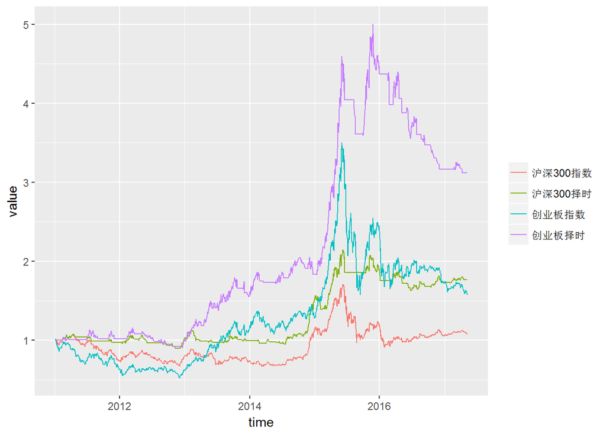

择时模型和指数的收益率统计如下表：

|  | 沪深300指 | 沪深300LLT | 创业板指 | 创业板MA |
| --- | --- | --- | --- | --- |
| 2011-01-04 ~ 2011-12-30 | -25.0% | -2.5% | -35.9% | 1.9% |
| 2012-01-04 ~ 2012-12-31 | 7.6% | 5.4% | -2.1% | -1.7% |
| 2013-01-04 ~ 2013-12-31 | -7.6% | -3.2% | 82.7% | 55.7% |
| 2014-01-02 ~ 2014-12-31 | 51.7% | 52.4% | 12.8% | 17.7% |
| 2015-01-05 ~ 2015-12-31 | 5.6% | 24.3% | 84.4% | 138.1% |
| 2016-01-04 ~ 2016-12-30 | -11.3% | -8.1% | -27.7% | -27.5% |
| 2017-01-03 ~ 2017-05-08 | 1.5% | 1.9% | -8.8% | -1.6% |
| 累计收益率 | 7.4% | 76.7% | 57.2% | 211.7% |
| 年化收益率 | 1.1% | 9.4% | 7.4% | 19.6% |
| 年化波动率 | 24.0% | 15.4% | 32.6% | 21.9% |
| 年化Sharpe值 | 4.7% | 61.1% | 22.7% | 89.4% |
| 最大回撤 | 46.7% | 24.0% | 55.1% | 37.7% |

择时模型最近10个交易日的信号如下表：

| 日期 | 沪深300收盘价 | 沪深300LLT | 沪深300择时信号 | 创业板收盘价 | 创业板MA30 | 创业板择时信号 |
| --- | --- | --- | --- | --- | --- | --- |
| 2017-04-24 | 3431.259 | 3488.856 |  | 1809.911 | 1919.078 |  |
| 2017-04-25 | 3440.974 | 3486.717 |  | 1818.870 | 1914.707 |  |
| 2017-04-26 | 3445.183 | 3485.115 |  | 1820.481 | 1909.694 |  |
| 2017-04-27 | 3446.720 | 3483.757 |  | 1842.922 | 1905.857 |  |
| 2017-04-28 | 3439.753 | 3482.270 |  | 1850.734 | 1902.288 |  |
| 2017-05-02 | 3426.577 | 3480.182 |  | 1850.849 | 1898.425 |  |
| 2017-05-03 | 3413.128 | 3477.312 |  | 1840.453 | 1894.785 |  |
| 2017-05-04 | 3404.386 | 3473.844 |  | 1838.104 | 1890.928 |  |
| 2017-05-05 | 3382.550 | 3469.535 |  | 1818.191 | 1886.165 |  |
| 2017-05-08 | 3358.812 | 3463.940 |  | 1788.708 | 1880.836 |  |

### (d4)网格交易

在经历了三轮股灾，A股逐步回归正常，在过去的一段时间呈现一个震荡的格局，如果未来没有增量信息，很可能维持震荡。结合股指期货的贴水，前期研究了一下网格交易。网格交易的结果如下图：

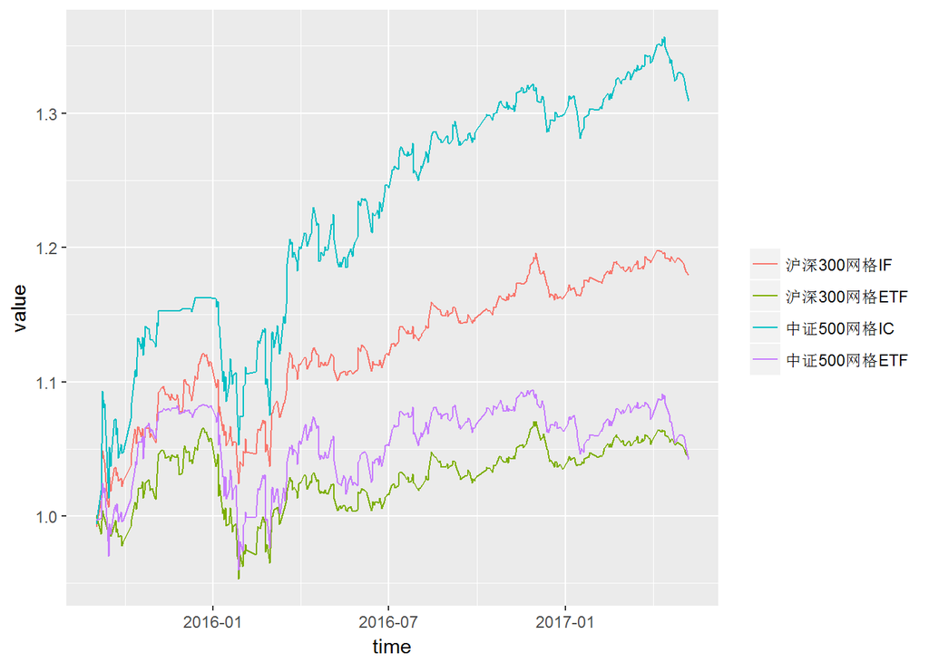

网格交易的收益统计如下表：

|  | 沪深300指数 | 沪深300网格IF | 沪深300网格ETF | 中证500指数 | 中证500网格IC | 中证500网格ETF |
| --- | --- | --- | --- | --- | --- | --- |
| 2015-09-02 ~ 2015-12-31 | 11.0% | 11.1% | 5.6% | 23.5% | 16.2% | 8.1% |
| 2016-01-04 ~ 2016-12-30 | -11.3% | 4.7% | -1.8% | -17.8% | 11.8% | -1.6% |
| 2017-01-03 ~ 2017-05-08 | 1.5% | 1.4% | 0.6% | -4.6% | 0.7% | -2.0% |
| 累计收益率 | -0.1% | 17.9% | 4.3% | -3.1% | 30.9% | 4.2% |
| 年化收益率 | -0.1% | 10.3% | 2.5% | -1.9% | 17.3% | 2.5% |
| 年化波动率 | 21.3% | 8.9% | 8.7% | 28.7% | 13.1% | 11.2% |
| 年化Sharpe值 | -0.3% | 115.5% | 29.3% | -6.5% | 131.9% | 22.2% |
| 最大回撤 | 26.4% | 8.6% | 10.5% | 33.5% | 9.4% | 11.4% |

## E、选股

### (e1)超级小盘股

作为多因子选股的第一部分，有必要从市值因子说起。 下面利用总市值因子，在中证全指的成分股内，选出市值最小的100只股票，这里剔除了ST、新上市、停牌和涨停的股票，100只股票等权配置，每月换仓一次，交易成本千分之三。超级小盘股策略的净值表现如下图。

[output not shown]

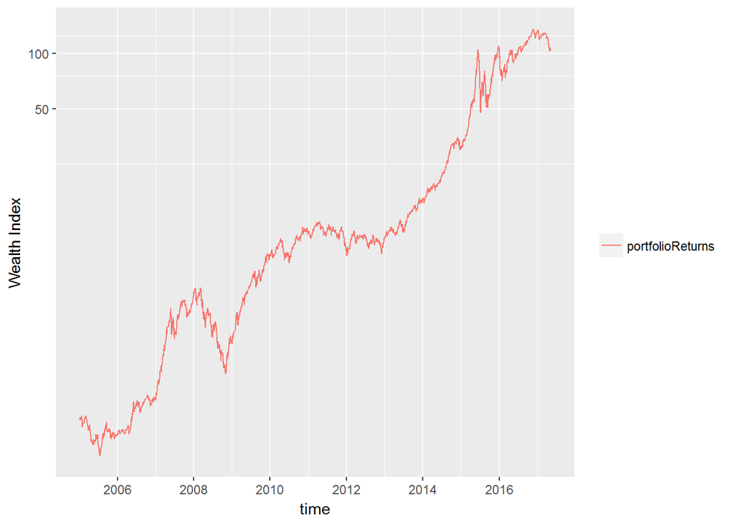

超级小盘股的收益统计如下表：

|  | 超级小盘股 | 沪深300 | 中证500 |
| --- | --- | --- | --- |
| 2005-01-05 ~ 2005-12-30 | -16.7% | -6.0% | -12.8% |
| 2006-01-04 ~ 2006-12-29 | 55.8% | 121.0% | 100.7% |
| 2007-01-04 ~ 2007-12-28 | 265.1% | 161.5% | 186.6% |
| 2008-01-02 ~ 2008-12-31 | -44.5% | -65.9% | -60.8% |
| 2009-01-05 ~ 2009-12-31 | 205.8% | 96.7% | 131.3% |
| 2010-01-04 ~ 2010-12-31 | 32.2% | -12.5% | 10.5% |
| 2011-01-04 ~ 2011-12-30 | -19.4% | -25.0% | -33.8% |
| 2012-01-04 ~ 2012-12-31 | 15.3% | 7.6% | 0.3% |
| 2013-01-04 ~ 2013-12-31 | 63.3% | -7.6% | 16.9% |
| 2014-01-02 ~ 2014-12-31 | 88.8% | 51.7% | 39.0% |
| 2015-01-05 ~ 2015-12-31 | 254.4% | 5.6% | 43.1% |
| 2016-01-04 ~ 2016-12-30 | 21.2% | -11.3% | -17.8% |
| 2017-01-03 ~ 2017-05-08 | -21.4% | 1.5% | -4.6% |
| 累计收益率 | 10177.0% | 241.8% | 507.5% |
| 年化收益率 | 45.6% | 10.5% | 15.7% |
| 年化波动率 | 35.7% | 28.3% | 32.3% |
| 年化Sharpe值 | 127.7% | 37.0% | 48.7% |
| 最大回撤 | 66.3% | 72.3% | 72.4% |

### (e2)银行股轮动

银行股轮动是参考集思录的热门贴银行股评级而来的，数据的提取和参数的设置和原贴有一定的差别，所以轮动的效果也会不太一样，不过回测的效果还不错，从现在开始跟踪。2013年以来银行股轮动的结果如下图：

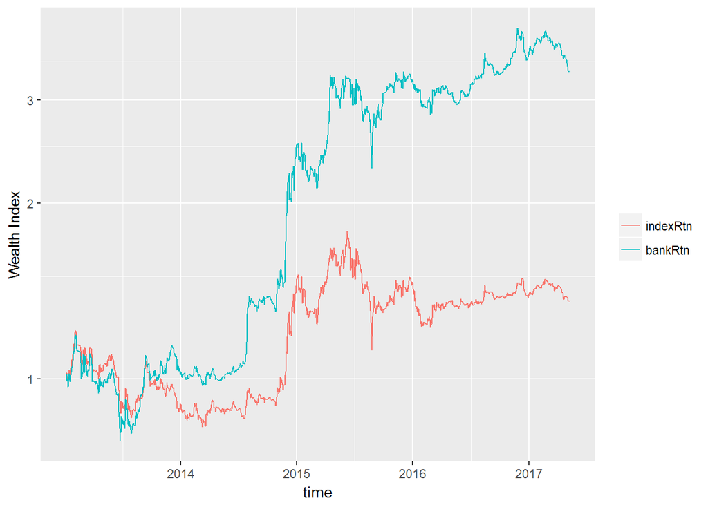

银行股轮动的收益统计如下表：

|  | 申万银行 | 银行股轮动 |
| --- | --- | --- |
| 2013-01-04 ~ 2013-12-31 | -9.2% | 3.0% |
| 2014-01-02 ~ 2014-12-31 | 63.2% | 144.5% |
| 2015-01-05 ~ 2015-12-31 | -1.4% | 29.0% |
| 2016-01-04 ~ 2016-12-30 | -4.9% | 10.5% |
| 2017-01-03 ~ 2017-05-08 | -2.0% | -6.5% |
| 累计收益率 | 36.2% | 235.8% |
| 年化收益率 | 7.4% | 32.1% |
| 年化波动率 | 27.9% | 31.8% |
| 年化Sharpe值 | 26.4% | 101.0% |
| 最大回撤 | 37.4% | 34.2% |

银行股轮动的最新得分如下表：

| 日期 | 代码 | 简称 | PB | 预期ROE | 翻倍期 | 持仓 |
| --- | --- | --- | --- | --- | --- | --- |
| 2017-05-08 | EQ600015 | 华夏银行 | 0.70 | 0.15 | 2.5 | hold |
| 2017-05-08 | EQ601818 | 光大银行 | 0.68 | 0.11 | 3.1 |  |
| 2017-05-08 | EQ601328 | 交通银行 | 0.69 | 0.10 | 3.3 |  |
| 2017-05-08 | EQ000001 | 平安银行 | 0.71 | 0.11 | 3.5 |  |
| 2017-05-08 | EQ601988 | 中国银行 | 0.72 | 0.11 | 3.5 |  |
| 2017-05-08 | EQ600016 | 民生银行 | 0.79 | 0.13 | 3.8 |  |
| 2017-05-08 | EQ601288 | 农业银行 | 0.80 | 0.13 | 3.9 |  |
| 2017-05-08 | EQ601998 | 中信银行 | 0.74 | 0.10 | 4.0 |  |
| 2017-05-08 | EQ601166 | 兴业银行 | 0.82 | 0.13 | 4.1 |  |
| 2017-05-08 | EQ600000 | 浦发银行 | 0.85 | 0.13 | 4.2 |  |
| 2017-05-08 | EQ601398 | 工商银行 | 0.86 | 0.13 | 4.5 |  |
| 2017-05-08 | EQ601939 | 建设银行 | 0.91 | 0.13 | 4.8 |  |
| 2017-05-08 | EQ601009 | 南京银行 | 0.95 | 0.14 | 5.1 |  |
| 2017-05-08 | EQ601169 | 北京银行 | 0.89 | 0.12 | 5.1 |  |
| 2017-05-08 | EQ600036 | 招商银行 | 1.13 | 0.14 | 6.0 |  |
| 2017-05-08 | EQ002142 | 宁波银行 | 1.25 | 0.16 | 6.2 |  |
| 2017-05-08 | EQ601229 | 上海银行 | 1.11 | 0.12 | 6.9 |  |
| 2017-05-08 | EQ601997 | 贵阳银行 | 1.55 | 0.17 | 7.2 |  |
| 2017-05-08 | EQ600919 | 江苏银行 | 1.23 | 0.13 | 7.4 |  |
| 2017-05-08 | EQ600926 | 杭州银行 | 1.42 | 0.11 | 10.3 |  |
| 2017-05-08 | EQ601128 | 常熟银行 | 2.88 | 0.10 | 17.6 |  |
| 2017-05-08 | EQ603323 | 吴江银行 | 2.73 | 0.08 | 21.9 |  |
| 2017-05-08 | EQ002807 | 江阴银行 | 3.22 | 0.09 | 22.8 |  |
| 2017-05-08 | EQ600908 | 无锡银行 | 4.93 | 0.10 | 23.8 |  |

## F、多因子跟踪

### (f1)近一个月周频因子IC

全市场因子IC表现如下图所示，根据因子IC均值大于0，胜率大于50%简单区分了一下alpha因子和风险因子。

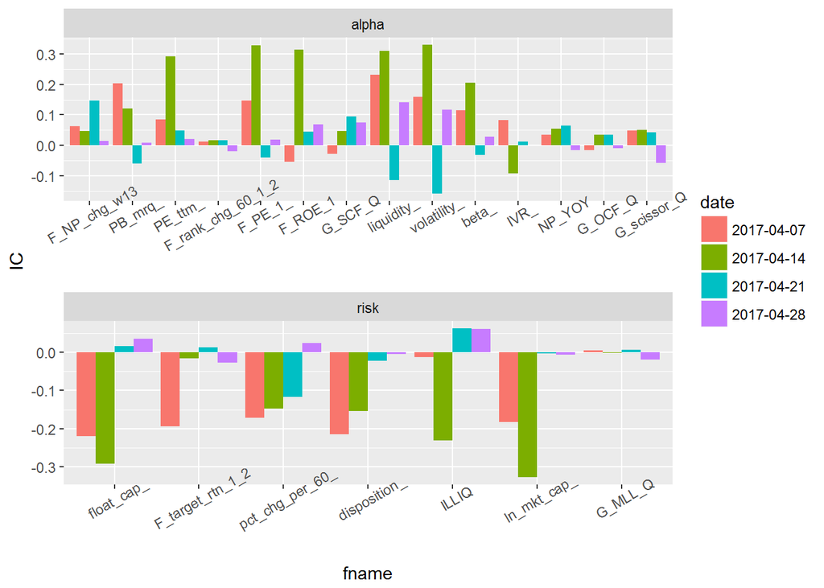

沪深300因子IC表现如下图所示。

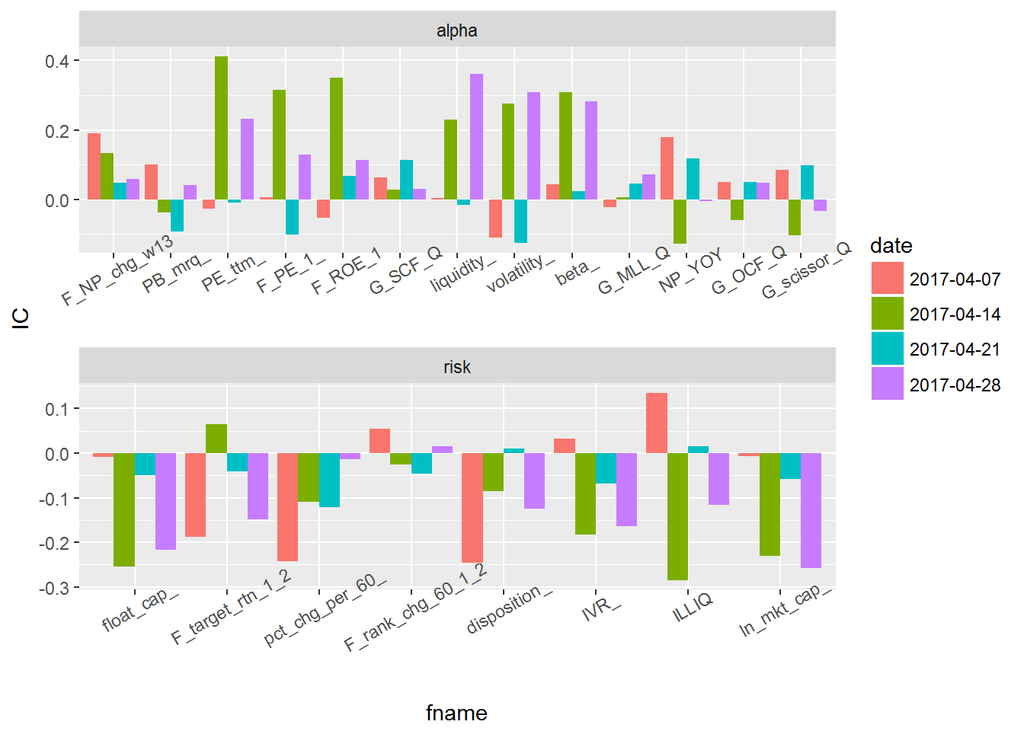

中证500因子IC表现如下图所示。

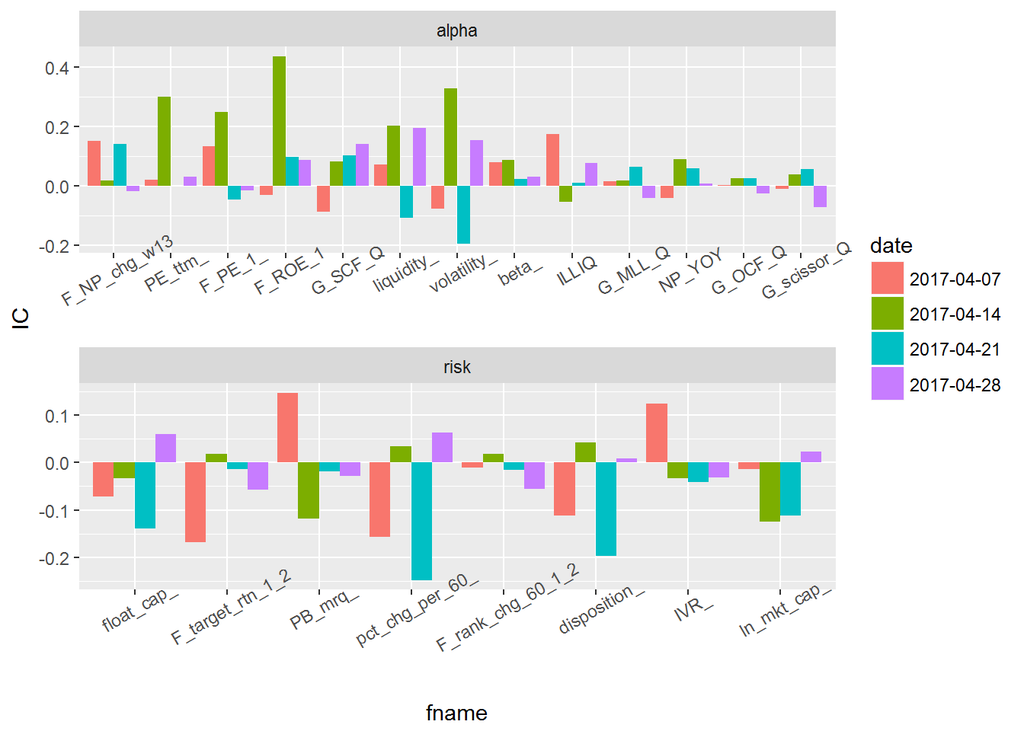

因子IC统计如下表所示。

| 因子名 | 全市场排名 | 全市场均值 | 全市场胜率 | 沪深300排名 | 沪深300均值 | 沪深300胜率 | 中证500排名 | 中证500均值 | 中证500胜率 |
| --- | --- | --- | --- | --- | --- | --- | --- | --- | --- |
| liquidity_ | 1 | 0.142 | 0.75 | 3 | 0.145 | 0.75 | 2 | 0.091 | 0.75 |
| F_PE_1_ | 2 | 0.113 | 0.75 | 6 | 0.087 | 0.75 | 4 | 0.081 | 0.50 |
| volatility_ | 3 | 0.112 | 0.75 | 7 | 0.087 | 0.50 | 8 | 0.053 | 0.50 |
| PE_ttm_ | 4 | 0.111 | 1.00 | 2 | 0.152 | 0.50 | 3 | 0.088 | 1.00 |
| F_ROE_1 | 5 | 0.093 | 0.75 | 4 | 0.119 | 0.75 | 1 | 0.148 | 0.75 |
| beta_ | 6 | 0.079 | 0.75 | 1 | 0.164 | 1.00 | 7 | 0.055 | 1.00 |
| PB_mrq_ | 7 | 0.069 | 0.75 | 13 | 0.002 | 0.50 | 15 | -0.005 | 0.25 |
| F_NP_chg_w13 | 8 | 0.067 | 1.00 | 5 | 0.107 | 1.00 | 5 | 0.074 | 0.75 |
| G_SCF_Q | 9 | 0.047 | 0.75 | 8 | 0.059 | 1.00 | 6 | 0.060 | 0.75 |
| NP_YOY | 10 | 0.035 | 0.75 | 9 | 0.041 | 0.50 | 10 | 0.029 | 0.75 |
| G_scissor_Q | 11 | 0.021 | 0.75 | 12 | 0.011 | 0.50 | 14 | 0.003 | 0.50 |
| G_OCF_Q | 12 | 0.011 | 0.50 | 11 | 0.022 | 0.75 | 12 | 0.007 | 0.75 |
| F_rank_chg_60_1_2 | 13 | 0.007 | 0.75 | 14 | -0.001 | 0.50 | 16 | -0.016 | 0.25 |
| IVR_ | 14 | 0.001 | 0.75 | 17 | -0.096 | 0.25 | 13 | 0.004 | 0.25 |
| G_MLL_Q | 15 | -0.003 | 0.50 | 10 | 0.025 | 0.75 | 11 | 0.015 | 0.75 |
| ILLIQ | 16 | -0.030 | 0.50 | 15 | -0.062 | 0.50 | 9 | 0.052 | 0.75 |
| F_target_rtn_1_2 | 17 | -0.056 | 0.25 | 16 | -0.078 | 0.25 | 18 | -0.055 | 0.25 |
| disposition_ | 18 | -0.099 | 0.00 | 18 | -0.111 | 0.25 | 20 | -0.065 | 0.50 |
| pct_chg_per_60_ | 19 | -0.103 | 0.25 | 19 | -0.122 | 0.00 | 21 | -0.077 | 0.50 |
| float_cap_ | 20 | -0.115 | 0.50 | 20 | -0.132 | 0.00 | 17 | -0.046 | 0.25 |
| ln_mkt_cap_ | 21 | -0.130 | 0.00 | 21 | -0.139 | 0.00 | 19 | -0.056 | 0.25 |

### (f2)近一个月周频因子分组超额收益

全市场，不同时间段，根据因子得分分为10组，得分最高的组**超额**收益率如下图所示，根据累计收益率大于0和区间收益率为正概率大于0.5,简单区分了alpha因子和风险因子。

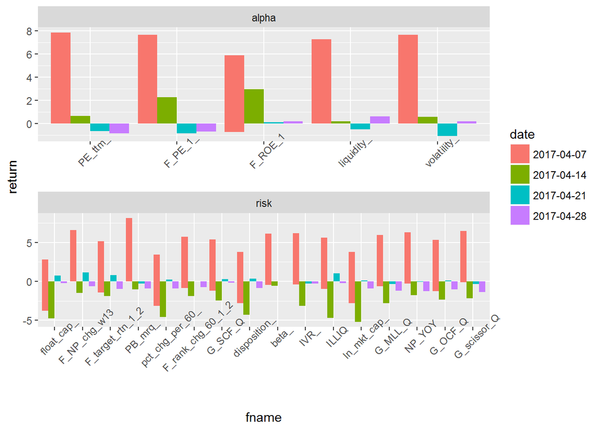

沪深300内得分最高的组**超额**收益率如下图所示。

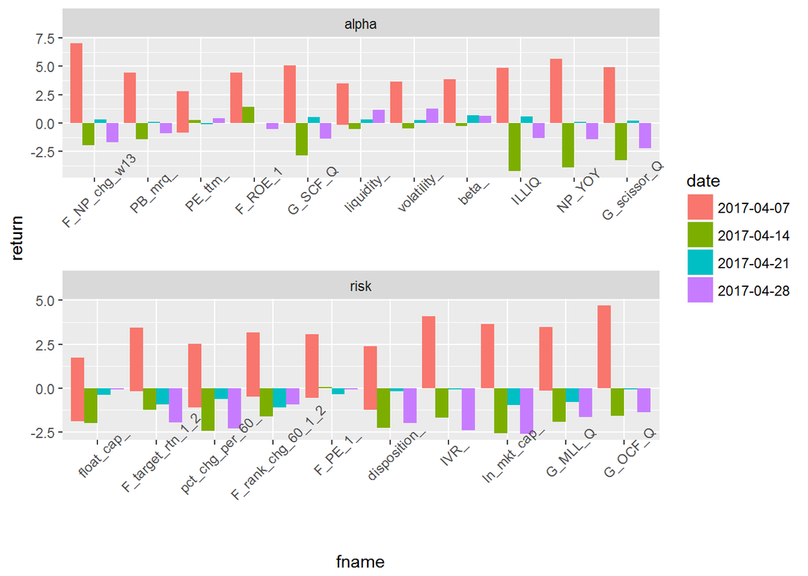

中证500内得分最高的组**超额**收益率如下图所示。

[figure not shown]

各个样本空间内，因子得分最高的一组和得分最低的一组的**超额**累积收益率统计如下表所示。

| 因子名 | 全市场Q1 | 全市场Q10 | 沪深300Q1 | 沪深300Q10 | 中证500Q1 | 中证500Q10 |
| --- | --- | --- | --- | --- | --- | --- |
| F_PE_1_ | 9.6 | -1.2 | 2.1 | 1.1 | 5.4 | 2.2 |
| F_ROE_1 | 8.6 | 1.0 | 6.3 | -2.8 | 11.6 | -0.9 |
| volatility_ | 8.5 | -4.9 | 4.7 | 1.6 | 10.2 | 8.5 |
| PE_ttm_ | 8.4 | -2.3 | 2.5 | -5.6 | 8.6 | 3.7 |
| liquidity_ | 8.4 | -7.6 | 4.3 | -4.1 | 8.5 | 2.8 |
| PB_mrq_ | 7.3 | -3.3 | 2.9 | 0.0 | 8.3 | 7.3 |
| F_NP_chg_w13 | 5.5 | 1.3 | 7.0 | -2.0 | 12.1 | 3.2 |
| beta_ | 5.0 | -2.2 | 5.2 | -6.5 | 11.2 | 3.4 |
| NP_YOY | 2.8 | -1.5 | 2.2 | -1.8 | 5.1 | 4.0 |
| G_scissor_Q | 2.3 | -0.1 | 0.7 | -1.8 | 4.6 | 5.3 |
| F_rank_chg_60_1_2 | 2.0 | 0.9 | -1.0 | -2.0 | 7.8 | 9.1 |
| IVR_ | 1.8 | -0.8 | 0.3 | 3.2 | 10.3 | 3.0 |
| G_SCF_Q | 1.7 | -1.2 | 2.7 | -0.9 | 7.1 | 5.6 |
| F_target_rtn_1_2 | 1.5 | 9.4 | -1.0 | 9.2 | 3.8 | 10.3 |
| G_MLL_Q | 0.7 | 0.5 | -1.1 | -1.3 | 7.2 | 6.1 |
| G_OCF_Q | 0.6 | -0.3 | 2.6 | -0.9 | 6.8 | 5.3 |
| ILLIQ | 0.4 | 4.5 | 0.9 | 4.3 | 9.5 | 1.9 |
| disposition_ | -4.0 | 8.4 | -3.3 | 9.2 | 3.4 | 11.9 |
| pct_chg_per_60_ | -5.1 | 5.7 | -4.0 | 7.7 | 4.7 | 11.9 |
| ln_mkt_cap_ | -5.1 | 8.8 | -2.6 | 5.1 | 3.3 | 8.7 |
| float_cap_ | -5.3 | 8.8 | -2.7 | 5.1 | 3.4 | 11.6 |

### (f3)近一年月频因子IC

全市场因子IC表现如下图所示。

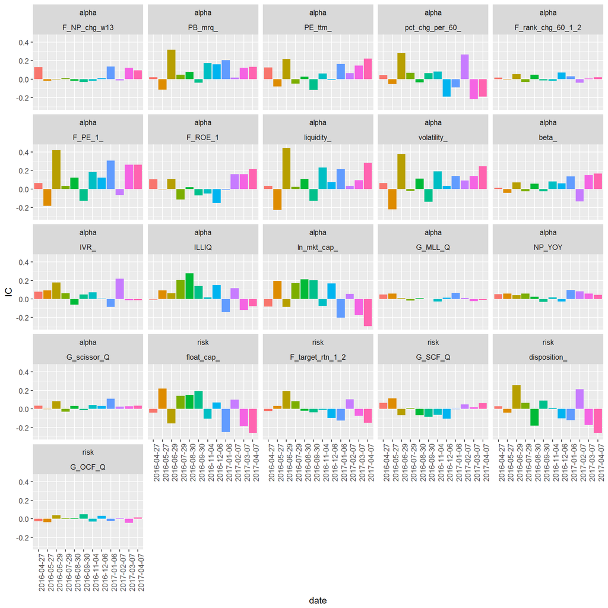

沪深300因子IC表现如下图所示。

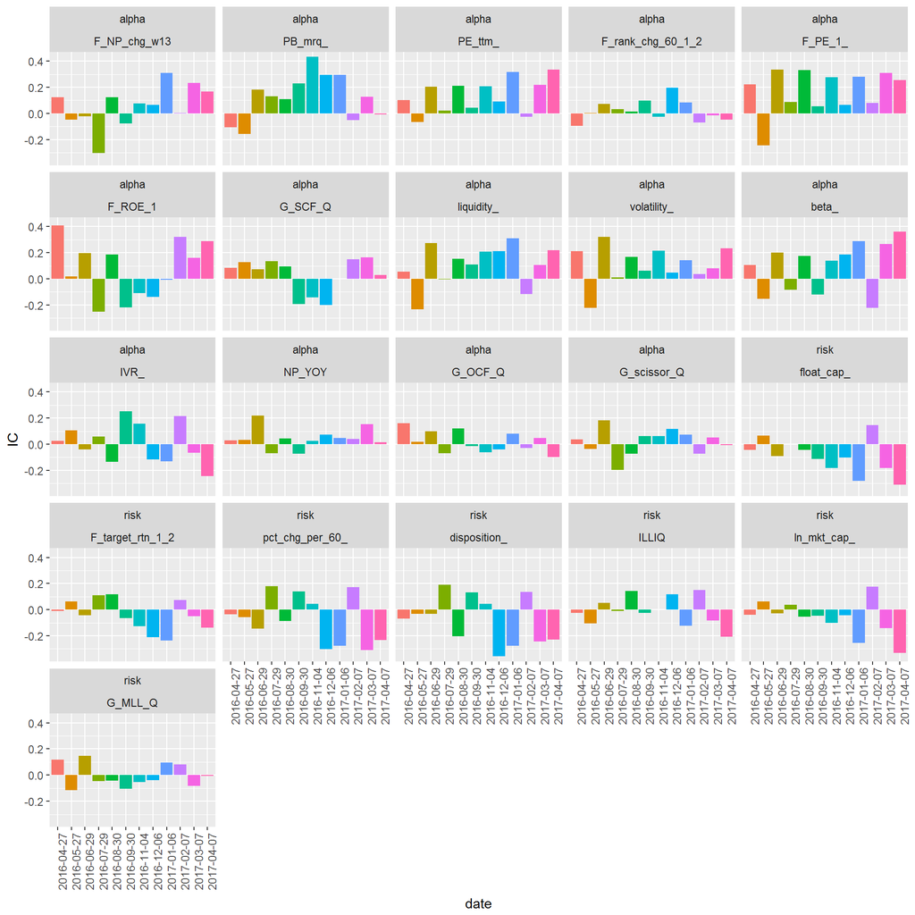

中证500因子IC表现如下图所示。

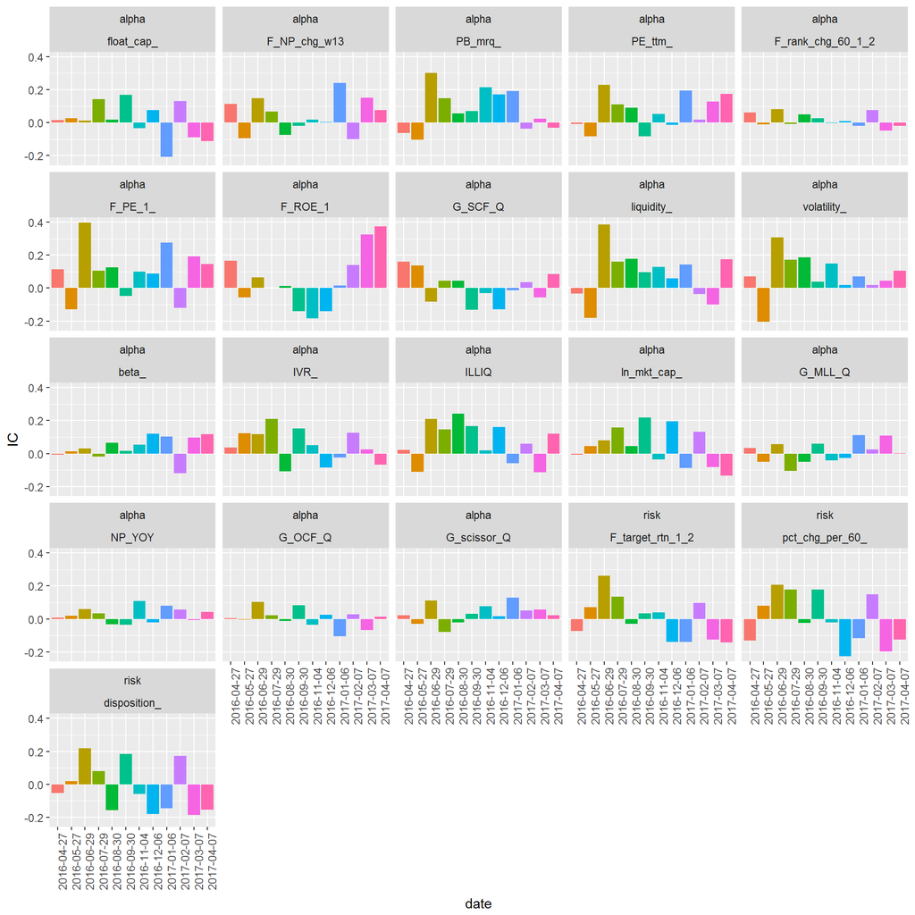

因子IC统计如下表所示。

|  | 因子名 | 全市场排名 | 全市场均值 | 全市场胜率 | 沪深300排名 | 沪深300均值 | 沪深300胜率 | 中证500排名 | 中证500均值 | 中证500胜率 |
| --- | --- | --- | --- | --- | --- | --- | --- | --- | --- | --- |
| 22 | F_PE_1_ | 1 | 0.117 | 0.75 | 1 | 0.171 | 0.92 | 1 | 0.104 | 0.75 |
| 23 | liquidity_ | 2 | 0.099 | 0.83 | 5 | 0.107 | 0.75 | 3 | 0.081 | 0.67 |
| 24 | PB_mrq_ | 3 | 0.093 | 0.83 | 3 | 0.122 | 0.67 | 4 | 0.079 | 0.67 |
| 25 | volatility_ | 4 | 0.085 | 0.75 | 4 | 0.109 | 0.92 | 2 | 0.081 | 0.92 |
| 26 | PE_ttm_ | 5 | 0.064 | 0.67 | 2 | 0.138 | 0.83 | 6 | 0.067 | 0.67 |
| 27 | ILLIQ | 6 | 0.060 | 0.67 | 16 | -0.010 | 0.42 | 5 | 0.071 | 0.75 |
| 28 | IVR_ | 7 | 0.048 | 0.67 | 14 | 0.007 | 0.50 | 8 | 0.046 | 0.67 |
| 29 | beta_ | 8 | 0.043 | 0.67 | 6 | 0.095 | 0.67 | 11 | 0.039 | 0.75 |
| 30 | NP_YOY | 9 | 0.039 | 0.83 | 9 | 0.045 | 0.83 | 13 | 0.026 | 0.67 |
| 31 | F_NP_chg_w13 | 10 | 0.033 | 0.50 | 8 | 0.054 | 0.67 | 10 | 0.044 | 0.67 |
| 32 | G_scissor_Q | 11 | 0.031 | 0.75 | 13 | 0.016 | 0.58 | 12 | 0.032 | 0.75 |
| 33 | F_ROE_1 | 12 | 0.031 | 0.50 | 7 | 0.071 | 0.58 | 7 | 0.048 | 0.67 |
| 34 | F_rank_chg_60_1_2 | 13 | 0.011 | 0.58 | 11 | 0.020 | 0.58 | 14 | 0.016 | 0.50 |
| 35 | G_MLL_Q | 14 | 0.011 | 0.58 | 15 | -0.004 | 0.33 | 16 | 0.010 | 0.58 |
| 36 | ln_mkt_cap_ | 15 | 0.007 | 0.50 | 18 | -0.064 | 0.25 | 9 | 0.044 | 0.58 |
| 37 | pct_chg_per_60_ | 16 | 0.003 | 0.50 | 19 | -0.076 | 0.33 | 20 | -0.004 | 0.42 |
| 38 | G_OCF_Q | 17 | -0.001 | 0.58 | 12 | 0.018 | 0.50 | 18 | 0.005 | 0.58 |
| 39 | G_SCF_Q | 18 | -0.006 | 0.50 | 10 | 0.027 | 0.67 | 17 | 0.005 | 0.50 |
| 40 | float_cap_ | 19 | -0.011 | 0.50 | 21 | -0.095 | 0.17 | 15 | 0.013 | 0.67 |
| 41 | F_target_rtn_1_2 | 20 | -0.011 | 0.33 | 17 | -0.043 | 0.33 | 19 | -0.001 | 0.50 |
| 42 | disposition_ | 21 | -0.018 | 0.50 | 20 | -0.079 | 0.33 | 21 | -0.021 | 0.42 |

### (f4)近一年月频因子分组超额收益

全市场，不同时间段，根据因子得分分为10组，得分最高的组**超额**收益率如下图所示，根据累计收益率大于0和区间收益率为正概率大于0.5,简单区分了alpha因子和风险因子。

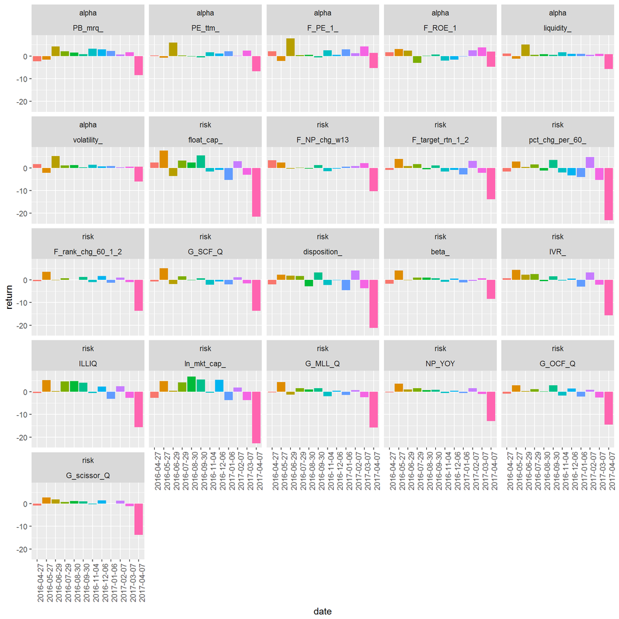

沪深300内得分最高的组**超额**收益率如下图所示。

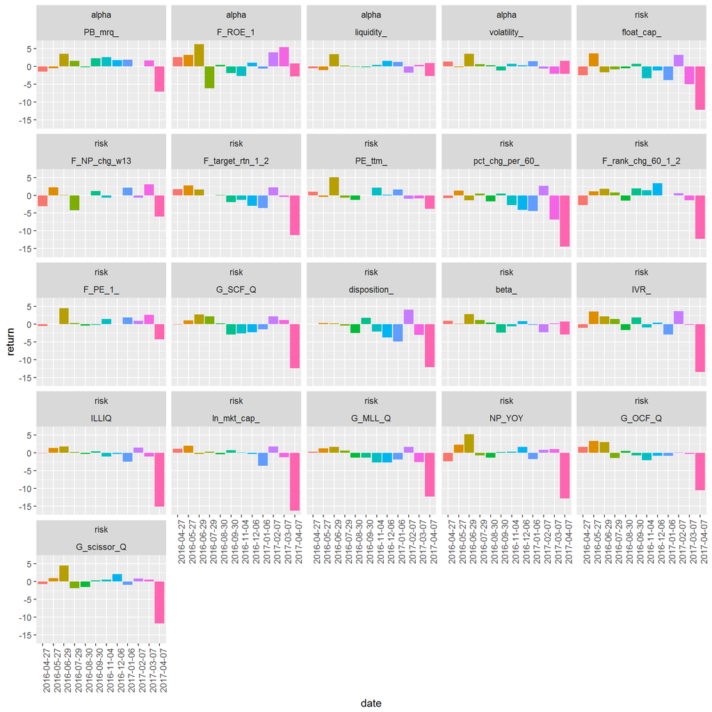

中证500内得分最高的组**超额**收益率如下图所示。

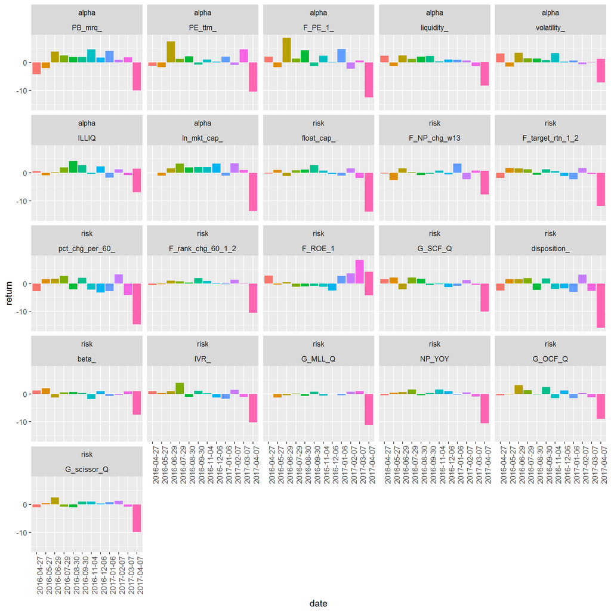

各个样本空间内，因子得分最高的一组和得分最低的一组的**超额**累积收益率统计如下表所示。

|  | 因子名 | 全市场Q1 | 全市场Q10 | 沪深300Q1 | 沪深300Q10 | 中证500Q1 | 中证500Q10 |
| --- | --- | --- | --- | --- | --- | --- | --- |
| 22 | F_PE_1_ | 15.5 | -25.5 | 5.6 | -27.6 | 5.8 | -22.7 |
| 23 | PB_mrq_ | 6.4 | -29.3 | 6.4 | -22.0 | 6.7 | -16.3 |
| 24 | liquidity_ | 6.2 | -34.5 | 2.1 | -22.8 | 2.4 | -22.9 |
| 25 | volatility_ | 4.9 | -27.4 | 4.2 | -25.1 | 6.7 | -20.2 |
| 26 | PE_ttm_ | 4.8 | -21.8 | 1.6 | -27.6 | 3.3 | -17.0 |
| 27 | F_ROE_1 | 3.9 | -15.0 | 9.8 | -16.0 | 10.4 | -16.2 |
| 28 | ILLIQ | -0.9 | -14.6 | -14.8 | 1.2 | 4.2 | -25.2 |
| 29 | F_NP_chg_w13 | -2.9 | -18.6 | -6.3 | -19.9 | -6.7 | -19.3 |
| 30 | beta_ | -5.3 | -25.0 | -1.8 | -31.3 | -4.5 | -24.7 |
| 31 | NP_YOY | -6.4 | -20.0 | -8.3 | -16.5 | -7.2 | -14.6 |
| 32 | G_scissor_Q | -6.5 | -16.1 | -7.7 | -15.8 | -6.7 | -14.6 |
| 33 | ln_mkt_cap_ | -7.2 | -0.8 | -15.9 | 6.7 | 2.7 | -8.5 |
| 34 | IVR_ | -7.3 | -19.2 | -7.9 | -6.1 | -6.8 | -10.9 |
| 35 | F_rank_chg_60_1_2 | -9.8 | -13.9 | -7.3 | -14.1 | -6.1 | -8.4 |
| 36 | F_target_rtn_1_2 | -12.4 | -4.6 | -12.9 | -3.0 | -9.9 | -5.6 |
| 37 | G_OCF_Q | -12.5 | -13.7 | -8.5 | -11.9 | -5.7 | -8.4 |
| 38 | float_cap_ | -13.1 | -1.7 | -21.3 | 9.4 | -10.1 | -7.8 |
| 39 | G_SCF_Q | -14.0 | -15.6 | -12.7 | -18.8 | -7.6 | -16.3 |
| 40 | G_MLL_Q | -14.1 | -14.7 | -18.5 | -13.0 | -12.0 | -9.3 |
| 41 | disposition_ | -22.6 | -11.3 | -21.2 | -1.2 | -19.3 | -8.7 |
| 42 | pct_chg_per_60_ | -25.7 | -15.8 | -27.9 | 1.6 | -19.7 | -13.7 |